# Rlearning

2024-11-15

# 加载库

```r
library(car)
library(tidyverse) # 加载tidyverse包
library(psych) # 加载psych包
```

```r
library(ggmosaic)
```

# 指定图形中的中文字体

```r
par(family = "STKaiti")
library(showtext)
showtext_auto()
```

# 数据管理

## 数据导入

```r
library(readr) # 加载readr包
library(readxl) # 加载readxl包
# datafile <- read_excel(file.choose()) # 读取Excel文件
  datafile <- read_excel("BMI.xlsx") # 读取Excel文件
# datafile <- read_csv("test.csv") # 读取Excel文件
datafile <- datafile %>%
  rename(height = "身高",
         weight = "体重",
         gender = "性别",
         attitude = "态度"
         ) # 对变量进行重命名
```

## 数据集基本信息

```r
datafile %>%
  head() # 查看数据集的前几行
```

```
## # A tibble: 6 × 6
##      id gender height weight attitude   BMI
##   <dbl>  <dbl>  <dbl>  <dbl>    <dbl> <dbl>
## 1     1      1    180     85        3  26.2
## 2     2      0    165     62        2  22.8
## 3     3      0    168     65        1  23.0
## 4     4      1    175     65        1  21.2
## 5     5      1    165     63        1  23.1
## 6     6      1    168     60        3  21.3
```

```r
datafile %>%
  str() # 查看数据集的结构
```

```
## tibble [14 × 6] (S3: tbl_df/tbl/data.frame)
##  $ id      : num [1:14] 1 2 3 4 5 6 7 8 9 10 ...
##  $ gender  : num [1:14] 1 0 0 1 1 1 1 1 1 0 ...
##  $ height  : num [1:14] 180 165 168 175 165 168 175 170 165 163 ...
##  $ weight  : num [1:14] 85 62 65 65 63 60 70 64 58 55 ...
##  $ attitude: num [1:14] 3 2 1 1 1 3 3 3 2 2 ...
##  $ BMI     : num [1:14] 26.2 22.8 23 21.2 23.1 ...
```

```r
datafile %>%
  dim() # 查看数据集的维度
```

```
## [1] 14  6
```

```r
datafile %>%
  nrow()  # 查看数据集的行数
```

```
## [1] 14
```

```r
datafile %>%
  ncol()  # 查看数据集的列数
```

```
## [1] 6
```

```r
datafile %>%
  attributes() # 查看数据集的属性
```

```
## $class
## [1] "tbl_df"     "tbl"        "data.frame"
##
## $row.names
##  [1]  1  2  3  4  5  6  7  8  9 10 11 12 13 14
##
## $names
## [1] "id"       "gender"   "height"   "weight"   "attitude" "BMI"
```

```r
datafile %>%
  class() # 查看数据集的类别
```

```
## [1] "tbl_df"     "tbl"        "data.frame"
```

```r
datafile %>%
  names() # 查看数据集的变量名
```

```
## [1] "id"       "gender"   "height"   "weight"   "attitude" "BMI"
```

```r
datafile %>%
  summary() # 查看数据集的描述性统计
```

```
##        id            gender        height          weight         attitude
##  Min.   : 1.00   Min.   :0.0   Min.   :158.0   Min.   :45.00   Min.   :1.000
##  1st Qu.: 4.25   1st Qu.:0.0   1st Qu.:163.5   1st Qu.:52.75   1st Qu.:1.000
##  Median : 7.50   Median :0.5   Median :165.5   Median :61.00   Median :2.000
##  Mean   : 7.50   Mean   :0.5   Mean   :167.0   Mean   :60.36   Mean   :1.857
##  3rd Qu.:10.75   3rd Qu.:1.0   3rd Qu.:169.5   3rd Qu.:64.75   3rd Qu.:2.750
##  Max.   :14.00   Max.   :1.0   Max.   :180.0   Max.   :85.00   Max.   :3.000
##       BMI
##  Min.   :18.03
##  1st Qu.:20.41
##  Median :21.28
##  Mean   :21.50
##  3rd Qu.:22.84
##  Max.   :26.23
```

```r
#-------------------------------------------------
datafile %>%
  as_tibble() # 将数据集转换为tibble格式
```

```
## # A tibble: 14 × 6
##       id gender height weight attitude   BMI
##    <dbl>  <dbl>  <dbl>  <dbl>    <dbl> <dbl>
##  1     1      1    180     85        3  26.2
##  2     2      0    165     62        2  22.8
##  3     3      0    168     65        1  23.0
##  4     4      1    175     65        1  21.2
##  5     5      1    165     63        1  23.1
##  6     6      1    168     60        3  21.3
##  7     7      1    175     70        3  22.9
##  8     8      1    170     64        3  22.1
##  9     9      1    165     58        2  21.3
## 10    10      0    163     55        2  20.7
## 11    11      0    158     45        1  18.0
## 12    12      0    160     50        1  19.5
## 13    13      0    166     51        1  18.5
## 14    14      0    160     52        2  20.3
```

## 宽型转长型格式

```
# 方法一
datafile_long <-
  datafile %>%
  pivot_longer(
    cols = c(time1, time2),
    names_to = "time",
    values_to = "value"
    ) # 宽型转长型
```

```r
# 方法二
# 示例数据：某实验前后测量的体重数据（单位：kg）
before <- c(70, 68, 75, 80, 72, 78, 74)
after <- c(68, 67, 73, 78, 71, 76, 73)
data <- data.frame(
  subject = rep(1:length(before),2),
  Group = rep(c("Before", "After"), each = length(before)),
  Weight = c(before, after)
)
data
```

```
##    subject  Group Weight
## 1        1 Before     70
## 2        2 Before     68
## 3        3 Before     75
## 4        4 Before     80
## 5        5 Before     72
## 6        6 Before     78
## 7        7 Before     74
## 8        1  After     68
## 9        2  After     67
## 10       3  After     73
## 11       4  After     78
## 12       5  After     71
## 13       6  After     76
## 14       7  After     73
```

```r
# 方法三
set.seed(123)
data <- data.frame(
  Subject = factor(1:10),
  Time1 = rnorm(10, mean = 70, sd = 5),
  Time2 = rnorm(10, mean = 75, sd = 5),
  Time3 = rnorm(10, mean = 80, sd = 5)
)

# 将数据转换为长格式
long_data <- gather(data, key = "Time", value = "Score", Time1, Time2, Time3)
long_data
```

```
##    Subject  Time    Score
## 1        1 Time1 67.19762
## 2        2 Time1 68.84911
## 3        3 Time1 77.79354
## 4        4 Time1 70.35254
## 5        5 Time1 70.64644
## 6        6 Time1 78.57532
## 7        7 Time1 72.30458
## 8        8 Time1 63.67469
## 9        9 Time1 66.56574
## 10      10 Time1 67.77169
## 11       1 Time2 81.12041
## 12       2 Time2 76.79907
## 13       3 Time2 77.00386
## 14       4 Time2 75.55341
```

[output cut: 16 more lines]

# 独立样本t检验

```r
# 独立样本student's t test
t.result <-
  t.test(
    height ~ gender,
    data = datafile,
    var.equal = TRUE
    )
t.result
```

```
##
##  Two Sample t-test
##
## data:  height by gender
## t = -3.2339, df = 12, p-value = 0.007167
## alternative hypothesis: true difference in means between group 0 and group 1 is not equal to 0
## 95 percent confidence interval:
##  -13.868165  -2.703263
## sample estimates:
## mean in group 0 mean in group 1
##        162.8571        171.1429
```

```r
str(t.result)
```

```
## List of 10
##  $ statistic  : Named num -3.23
##   ..- attr(*, "names")= chr "t"
##  $ parameter  : Named num 12
##   ..- attr(*, "names")= chr "df"
##  $ p.value    : num 0.00717
##  $ conf.int   : num [1:2] -13.9 -2.7
##   ..- attr(*, "conf.level")= num 0.95
##  $ estimate   : Named num [1:2] 163 171
##   ..- attr(*, "names")= chr [1:2] "mean in group 0" "mean in group 1"
##  $ null.value : Named num 0
##   ..- attr(*, "names")= chr "difference in means between group 0 and group 1"
##  $ stderr     : num 2.56
##  $ alternative: chr "two.sided"
##  $ method     : chr " Two Sample t-test"
##  $ data.name  : chr "height by gender"
##  - attr(*, "class")= chr "htest"
```

```r
t.result$method
```

```
## [1] " Two Sample t-test"
```

```r
t.result$alternative
```

```
## [1] "two.sided"
```

```r
t.result$null.value
```

```
## difference in means between group 0 and group 1
##                                               0
```

```r
t.result$estimate
```

```
## mean in group 0 mean in group 1
##        162.8571        171.1429
```

```r
t.result$statistic
```

```
##         t
## -3.233888
```

```r
t.result$parameter
```

```
## df
## 12
```

```r
t.result$p.value
```

```
## [1] 0.00716743
```

```r
t.result$stderr
```

```
## [1] 2.562153
```

```r
t.result$conf.int[1]
```

```
## [1] -13.86817
```

```r
t.result$conf.int[2]
```

```
## [1] -2.703263
```

```r
t.result$conf.int
```

```
## [1] -13.868165  -2.703263
## attr(,"conf.level")
## [1] 0.95
```

```r
# 独立样本Welch's t检验
t.test(height ~ gender, data = datafile)
```

```
##
##  Welch Two Sample t-test
##
## data:  height by gender
## t = -3.2339, df = 10.248, p-value = 0.00869
## alternative hypothesis: true difference in means between group 0 and group 1 is not equal to 0
## 95 percent confidence interval:
##  -13.975874  -2.595555
## sample estimates:
## mean in group 0 mean in group 1
##        162.8571        171.1429
```

```r
# Welch's t-test的具体计算
result <- datafile %>%
  group_by(gender) %>%
  summarise(
    n = n(),
    mean = mean(height, na.rm = TRUE),
    sd = sd(height, na.rm = TRUE)
    ) # 按性别对身高进行描述性统计
mean(datafile$height[datafile$gender == 0])
```

```
## [1] 162.8571
```

```r
mean(datafile$height[datafile$gender == 1])
```

```
## [1] 171.1429
```

```r
t.value <- (result[1,3] - result[2,3])/sqrt(result[1,4]^2/result[1,2] + result[2,4]^2/result[2,2]) # 计算t值
# 计算Welch-Satterthwaite自由度
df.value <- (result[1,4]^2/result[1,2] + result[2,4]^2/result[2,2])^2/((result[1,4]^2/result[1,2])^2/(result[1,2]-1) + (result[2,4]^2/result[2,2])^2/(result[2,2]-1)) # 计算自由度
# 计算p值
t.value <- as.numeric(t.value)
df.value <- as.numeric(df.value)
p.value <- 2*pt(-abs(t.value), df.value)
t.value
```

```
## [1] -3.233888
```

```r
df.value
```

```
## [1] 10.24801
```

```r
p.value
```

```
## [1] 0.008689748
```

### **独立样本 t 检验简介**

**独立样本 t 检验** 用于比较两个独立组的均值是否存在显著差异。这种检验适用于一个定量变量和一个二分类分组变量。

#### **应用场景**

1. 比较两个实验组和对照组的效果。
2. 比较男性和女性在某一变量（如收入、身高）上的差异。
3. 在两组样本数据之间，判断是否有显著性差异。

#### **假设**

- **原假设 $H_0$**：两组均值相等（$\mu_1 = \mu_2$）。
- **备择假设 $H_1$**：
  - 双尾检验：两组均值不相等（$\mu_1 \neq \mu_2$）。
  - 单尾检验：一组均值大于或小于另一组（$\mu_1 > \mu_2$ 或 $\mu_1 < \mu_2$）。

#### **检验方法**

根据两组的方差是否相等，分为两种情况： 1. 方差相等：使用标准 t 检验。 2. 方差不相等：使用 Welch t 检验（更稳健）。

### **独立样本 t 检验的公式**

#### **检验统计量公式**

1. **当方差相等时**：
   $$t = \frac{\bar{X}_1 - \bar{X}_2}{\sqrt{s_p^2 \left(\frac{1}{n_1} +
   \frac{1}{n_2}\right)}}$$
   其中：
- $\bar{X}_1, \bar{X}_2$：两组样本均值。
- $n_1, n_2$：两组样本大小。
- $s_p^2$：两组的合并方差，计算公式为：
  $$s_p^2 = \frac{(n_1 - 1)s_1^2 + (n_2 - 1)s_2^2}{n_1 + n_2 - 2}$$
2. **当方差不相等（Welch t 检验）**：
   $$t = \frac{\bar{X}_1 - \bar{X}_2}{\sqrt{\frac{s_1^2}{n_1} +
   \frac{s_2^2}{n_2}}}$$
3. **自由度**： 对于 Welch t 检验，自由度根据以下公式计算：
   $$df = \frac{\left(\frac{s_1^2}{n_1} +
   \frac{s_2^2}{n_2}\right)^2}{\frac{\left(\frac{s_1^2}{n_1}\right)^2}{n_1
   - 1} + \frac{\left(\frac{s_2^2}{n_2}\right)^2}{n_2 - 1}}$$

### **在 R 中执行独立样本 t 检验**

#### **1. 示例数据**

```r
# 示例数据
data <- data.frame(
  score = c(85, 90, 78, 92, 88, 76, 95, 89, 80, 84),
  group = c("A", "A", "B", "B", "A", "B", "A", "A", "B", "B")
)
# 执行独立样本 t 检验
t_test_result <- t.test(score ~ group, data = data)

# 查看结果
print(t_test_result)
```

```
##
##  Welch Two Sample t-test
##
## data:  score by group
## t = 2.2665, df = 6.3952, p-value = 0.06128
## alternative hypothesis: true difference in means between group A and group B is not equal to 0
## 95 percent confidence interval:
##  -0.4709231 15.2709231
## sample estimates:
## mean in group A mean in group B
##            89.4            82.0
```

### **结果解释、注意事项与总结**

#### **结果解释**

1. **t 值**：表示两组均值差异的标准化大小，t 的绝对值越大，差异越显著。
2. **p 值**：用于判断均值是否存在显著差异：
   - p > 0.05：无法拒绝原假设，两组均值无显著差异。
   - p ≤ 0.05：拒绝原假设，认为两组均值有显著差异。
3. **自由度**：影响 t 值和 p 值的计算，自由度越大，检验效能越高。
4. **置信区间**：提供均值差异的范围。如果包含 0，则均值无显著差异。
5. **方差是否相等**：根据 `var.test()` 的结果判断方差是否齐性，影响 t 检验的计算方式。

#### **注意事项**

1. **方差齐性假设**：
   - 使用 `var.test()` 检验两组方差是否相等：

   ```r
   var.test(score ~ group, data = data)
   ```

   - 如果方差相等，可在 t 检验中设置 `var.equal = TRUE`。
2. **单尾检验**：
   - 如果假设组 A 均值大于组 B 均值，可设置 `alternative = "greater"`。
   - 如果假设组 A 均值小于组 B 均值，可设置 `alternative = "less"`。
3. **正态性检验**：
   - 小样本时（每组 < 30），需使用 `shapiro.test()` 检验正态性：

   ```r
   shapiro.test(data$score[data$group == "A"])
   shapiro.test(data$score[data$group == "B"])
   ```

   - 如果数据不满足正态性假设，建议使用非参数检验（如 `wilcox.test()`）。
4. **样本量影响**：
   - 样本量过小时，p 值可能不够稳定；建议结合效应量分析。

#### **总结**

独立样本 t 检验是比较两组均值差异的重要工具。在 R 中，使用 `t.test()` 可快速实现： - 若方差齐性假设成立，可使用标准 t 检验。 - 若方差不齐性成立，默认使用 Welch t 检验。

在分析中，应根据数据的正态性、样本量和方差情况选择合适的检验方法。如不满足正态性假设，可用非参数检验替代。

# 两总体方差齐性检验

```r
# F test
var.test(height ~ gender, data = datafile)
```

```
##
##  F test to compare two variances
##
## data:  height by gender
## F = 0.41496, num df = 6, denom df = 6, p-value = 0.3086
## alternative hypothesis: true ratio of variances is not equal to 1
## 95 percent confidence interval:
##  0.07130127 2.41494298
## sample estimates:
## ratio of variances
##           0.414956
```

```r
# Levene's test
leveneTest(
  height ~ factor(gender),
  data = datafile
)
```

```
## Levene's Test for Homogeneity of Variance (center = median)
##       Df F value Pr(>F)
## group  1  1.3698 0.2646
##       12
```

```r
# Bartlett's test
bartlett.test(height ~ factor(gender),
              data = datafile)
```

```
##
##  Bartlett test of homogeneity of variances
##
## data:  height by factor(gender)
## Bartlett's K-squared = 1.0384, df = 1, p-value = 0.3082
```

## **Bartlett’s Test**

### **Bartlett’s Test 的原理**

Bartlett’s Test 的原假设和备择假设如下：

- **原假设 $H_0$**：所有组的方差相等。
- **备择假设 $H_1$**：至少有一组的方差不同。

#### **公式**

检验统计量 $T$ 的公式为：

$$T = \frac{(N - k) \ln(S^2) - \sum_{i=1}^{k} (n_i - 1) \ln(S_i^2)}{1 +
\frac{1}{3(k-1)} \left(\sum_{i=1}^{k} \frac{1}{n_i - 1} - \frac{1}{N -
k}\right)}$$

其中：

- $N$：总样本数。
- $k$：组数。
- $S^2$：整体样本的加权方差，计算公式为：

$$S^2 = \frac{\sum_{i=1}^{k} (n_i - 1) S_i^2}{N - k}$$

- $n_i$：第 $i$ 组的样本数。
- $S_i^2$：第 $i$ 组的样本方差。

Bartlett’s Test 的检验统计量 $T$ 近似服从 $\chi^2$ 分布，自由度为 $k - 1$。

### **Bartlett’s Test 的适用范围**

- Bartlett’s Test 适用于**正态分布**的数据。
- 对非正态数据，Bartlett’s Test 对偏态较敏感，可能失去检验效能。

如果数据非正态，建议使用更稳健的方法，例如 Levene’s Test。

### **在 R 中使用 Bartlett’s Test**

#### **1. 函数：`bartlett.test()`**

R 提供了内置的 `bartlett.test()` 函数，用于执行 Bartlett’s Test。

#### **2. 示例数据**

```r
# 示例数据
data <- data.frame(
  height = c(160, 165, 170, 155, 150, 145, 175, 180, 165, 160, 150, 155),
  group = c("A", "A", "A", "B", "B", "B", "C", "C", "C", "D", "D", "D")
)
```

#### **3. 运行Bartlett’s Test**

```r
# 执行 Bartlett's Test
result <- bartlett.test(height ~ group, data = data)

# 查看结果
print(result)
```

```
##
##  Bartlett test of homogeneity of variances
##
## data:  height by group
## Bartlett's K-squared = 0.50223, df = 3, p-value = 0.9184
```

#### **4. 输出解释**

运行 `bartlett.test()` 后，输出结果类似如下：

1. 检验统计量 $0.50223$，表明组间方差的差异程度。
2. 自由度 $df = 3$，表示数据中有 4 个组（$4 - 1 = 3$）。
3. p 值为 0.9184，大于 0.05，因此不能拒绝原假设，认为组间方差相等。

这意味着数据满足方差齐性的假设，可以继续执行单因素方差分析（ANOVA）。

### **Bartlett’s Test 的应用场景**

1. **方差齐性检验**： 在执行单因素方差分析（ANOVA）之前，验证分组数据是否满足方差齐性假设。
2. **组间方差比较**： 检查多个实验组的方差是否显著不同。

### **Bartlett’s Test 的优缺点**

#### **优点**

- 非常适合正态分布的数据。
- 是方差齐性检验的一种经典方法。

#### **缺点**

- 对正态性假设敏感。如果数据分布偏离正态，结果可能不准确。
- 对极端值和偏态数据较为敏感。

### **与 Levene’s Test 的对比**

| 特点 | Bartlett’s Test | Levene’s Test |
| --- | --- | --- |
| 正态性假设 | 需要满足正态性 | 不需要严格满足正态性 |
| 稳健性 | 对非正态数据敏感 | 对非正态数据更稳健 |
| 用途 | 用于正态数据的方差齐性检验 | 用于正态和非正态数据的方差齐性检验 |
| 极端值的影响 | 容易受到极端值影响 | 对极端值更稳健 |

### **代码完整示例**

以下是完整的代码示例：

```r
# 示例数据
data <- data.frame(
  height = c(160, 165, 170, 155, 150, 145, 175, 180, 165, 160, 150, 155),
  group = c("A", "A", "A", "B", "B", "B", "C", "C", "C", "D", "D", "D")
)

# 执行 Bartlett's Test
bartlett_result <- bartlett.test(height ~ group, data = data)

# 打印结果
print(bartlett_result)

# 检查数据正态性（以每组为单位）
by(data$height, data$group, shapiro.test)
```

## **Levene’s Test**

### **Levene’s Test 的原理**

Levene’s Test 的假设如下：

- **原假设 $H_0$**：所有组的方差相等。
- **备择假设 $H_1$**：至少有一组的方差与其他组不同。

#### **Levene’s Test 的基本过程**：

Levene’s Test 的检验统计量 $W$ 定义如下：

$$W = \frac{(N - k)}{(k - 1)} \cdot \frac{\sum_{i=1}^k n_i (Z_{i.} -
Z_{..})^2}{\sum_{i=1}^k \sum_{j=1}^{n_i} (Z_{ij} - Z_{i.})^2}$$

其中：

- $N$：总样本数。
- $k$：组数。
- $n_i$：第 $i$ 组的样本大小。
- $Z_{ij}$：第 $i$ 组中第 $j$ 个样本与其组中心（均值或中位数）的绝对偏差。
  $$Z_{ij} = |Y_{ij} - \text{center}_i|$$
  - 如果 `center` 选用均值：$\text{center}_i = \bar{Y}_i$；
  - 如果 `center` 选用中位数：$\text{center}_i = \text{median}(Y_i)$。
- $Z_{i.}$：第 $i$ 组的 $Z_{ij}$ 的均值。
- $Z_{..}$：所有 $Z_{ij}$ 的总体均值。

#### **公式解释**

- 分子表示组间偏差平方和，衡量组间差异。
- 分母表示组内偏差平方和，衡量组内差异。
- $W$ 服从 $F$ 分布，自由度为 $(k-1, N-k)$。

### **Levene’s Test 的适用范围**

- 数据可以是正态分布或非正态分布。
- 对于存在异常值的数据，Levene’s Test 更稳健。
- 分组变量应为因子型，响应变量应为定量型。

### **在 R 中使用 Levene’s Test**

#### **1. 函数：`leveneTest()`**

`leveneTest()` 是 R 中 **`car`** 包提供的函数，用于执行 Levene’s Test。

#### **2. 示例数据**

```r
# 示例数据
data <- data.frame(
  height = c(160, 165, 170, 155, 150, 145, 175, 180, 165, 160, 150, 155),
  group = c("A", "A", "A", "B", "B", "B", "C", "C", "C", "D", "D", "D")
)
# 如果尚未安装 car 包
# install.packages("car")

# 加载包
# library(car)
```

```r
# 执行 Levene’s Test
result <- leveneTest(height ~ group, data = data)
# 查看结果
print(result)
```

```
## Levene's Test for Homogeneity of Variance (center = median)
##       Df F value Pr(>F)
## group  3  0.1667 0.9159
##        8
```

#### **3. 结果解释**

1. **`F value`**：检验统计量，表示组间偏差的差异程度。
   - 在此结果中，$F = 0.1667$。
2. **`Df`**：自由度，包括组间自由度（$k - 1$）和组内自由度（$N - k$）。
   - 自由度 $Df = 3$ 表示有 4 个组（组间自由度为 $4 - 1 = 3$）。
3. **`Pr(>F)`**：p 值，用于判断是否拒绝原假设。
- 如果 p 值 > 0.05，则不能拒绝原假设，认为组间方差相等。
- 如果 p 值 ≤ 0.05，则拒绝原假设，认为至少有一组的方差与其他组不同。
- 在此结果中，$p = 0.9159$，大于 0.05，不能拒绝原假设，说明组间方差没有显著差异。

#### **注意**

- **中心选择的影响**：在默认情况下，Levene’s Test 使用中位数作为中心。如果数据接近正态分布，选择均值可能更合适。
- 结果解读需结合具体数据背景，尤其是在边界 p 值（如接近 0.05）时。

### **Levene’s Test 的中心选择**

`leveneTest()` 默认使用中位数作为中心计算偏差（`center = "median"`），适合非正态分布数据。

如果数据接近正态分布，可以选择均值作为中心：

```r
leveneTest(height ~ group, data = data, center = "mean")
```

### **Levene’s Test 的应用场景**

1. **单因素方差分析（ANOVA）**： 在 ANOVA 中，需要验证数据是否满足方差齐性假设。
2. **处理方差不齐的情况**： 如果方差不齐，可以使用更稳健的方法（如 Welch 方差分析）：

```r
   oneway.test(height ~ group, data = data)
```

### **Levene’s Test 的优缺点**

#### **优点**

- 对非正态分布数据稳健。
- 比 Bartlett’s Test 更适合包含异常值的数据。

#### **缺点**

- 在样本量特别小时，可能检验效能较低。
- 偏态数据仍可能影响结果。

### **代码完整示例**

```r
# 示例数据
data <- data.frame(
  height = c(160, 165, 170, 155, 150, 145, 175, 180, 165, 160, 150, 155),
  group = c("A", "A", "A", "B", "B", "B", "C", "C", "C", "D", "D", "D")
)

# 安装并加载 car 包
install.packages("car")
library(car)

# 执行 Levene’s Test
levene_result <- leveneTest(height ~ group, data = data)

# 打印结果
print(levene_result)

# 以均值为中心计算
leveneTest(height ~ group, data = data, center = "mean")
```

# 单因素方差分析

```r
# 单因素方差分析
 aov(height ~ factor(attitude),
      data = datafile)
```

```
## Call:
##    aov(formula = height ~ factor(attitude), data = datafile)
##
## Terms:
##                 factor(attitude) Residuals
## Sum of Squares          229.1667  286.8333
## Deg. of Freedom                2        11
##
## Residual standard error: 5.106443
## Estimated effects may be unbalanced
```

```r
aov.result <-
  aov(height ~ factor(attitude),
      data = datafile)
summary(aov.result)
```

```
##                  Df Sum Sq Mean Sq F value Pr(>F)
## factor(attitude)  2  229.2  114.58   4.394 0.0396 *
## Residuals        11  286.8   26.08
## ---
## Signif. codes:  0 '***' 0.001 '**' 0.01 '*' 0.05 '.' 0.1 ' ' 1
```

```r
str(aov.result)
```

```
## List of 13
##  $ coefficients : Named num [1:3] 165.33 -2.08 7.92
##   ..- attr(*, "names")= chr [1:3] "(Intercept)" "factor(attitude)2" "factor(attitude)3"
##  $ residuals    : Named num [1:14] 6.75 1.75 2.667 9.667 -0.333 ...
##   ..- attr(*, "names")= chr [1:14] "1" "2" "3" "4" ...
##  $ effects      : Named num [1:14] -624.86 8.87 12.26 7.94 -2.06 ...
##   ..- attr(*, "names")= chr [1:14] "(Intercept)" "factor(attitude)2" "factor(attitude)3" "" ...
##  $ rank         : int 3
##  $ fitted.values: Named num [1:14] 173 163 165 165 165 ...
##   ..- attr(*, "names")= chr [1:14] "1" "2" "3" "4" ...
##  $ assign       : int [1:3] 0 1 1
##  $ qr           :List of 5
##   ..$ qr   : num [1:14, 1:3] -3.742 0.267 0.267 0.267 0.267 ...
##   .. ..- attr(*, "dimnames")=List of 2
##   .. .. ..$ : chr [1:14] "1" "2" "3" "4" ...
##   .. .. ..$ : chr [1:3] "(Intercept)" "factor(attitude)2" "factor(attitude)3"
##   .. ..- attr(*, "assign")= int [1:3] 0 1 1
##   .. ..- attr(*, "contrasts")=List of 1
##   .. .. ..$ factor(attitude): chr "contr.treatment"
##   ..$ qraux: num [1:3] 1.27 1.46 1.35
##   ..$ pivot: int [1:3] 1 2 3
##   ..$ tol  : num 1e-07
##   ..$ rank : int 3
##   ..- attr(*, "class")= chr "qr"
##  $ df.residual  : int 11
##  $ contrasts    :List of 1
##   ..$ factor(attitude): chr "contr.treatment"
##  $ xlevels      :List of 1
##   ..$ factor(attitude): chr [1:3] "1" "2" "3"
##  $ call         : language aov(formula = height ~ factor(attitude), data = datafile)
##  $ terms        :Classes 'terms', 'formula'  language height ~ factor(attitude)
##   .. ..- attr(*, "variables")= language list(height, factor(attitude))
##   .. ..- attr(*, "factors")= int [1:2, 1] 0 1
##   .. .. ..- attr(*, "dimnames")=List of 2
##   .. .. .. ..$ : chr [1:2] "height" "factor(attitude)"
##   .. .. .. ..$ : chr "factor(attitude)"
##   .. ..- attr(*, "term.labels")= chr "factor(attitude)"
##   .. ..- attr(*, "order")= int 1
##   .. ..- attr(*, "intercept")= int 1
##   .. ..- attr(*, "response")= int 1
##   .. ..- attr(*, ".Environment")=<environment: R_GlobalEnv>
##   .. ..- attr(*, "predvars")= language list(height, factor(attitude))
##   .. ..- attr(*, "dataClasses")= Named chr [1:2] "numeric" "factor"
##   .. .. ..- attr(*, "names")= chr [1:2] "height" "factor(attitude)"
##  $ model        :'data.frame':   14 obs. of  2 variables:
##   ..$ height          : num [1:14] 180 165 168 175 165 168 175 170 165 163 ...
##   ..$ factor(attitude): Factor w/ 3 levels "1","2","3": 3 2 1 1 1 3 3 3 2 2 ...
##   ..- attr(*, "terms")=Classes 'terms', 'formula'  language height ~ factor(attitude)
##   .. .. ..- attr(*, "variables")= language list(height, factor(attitude))
##   .. .. ..- attr(*, "factors")= int [1:2, 1] 0 1
##   .. .. .. ..- attr(*, "dimnames")=List of 2
##   .. .. .. .. ..$ : chr [1:2] "height" "factor(attitude)"
##   .. .. .. .. ..$ : chr "factor(attitude)"
##   .. .. ..- attr(*, "term.labels")= chr "factor(attitude)"
##   .. .. ..- attr(*, "order")= int 1
##   .. .. ..- attr(*, "intercept")= int 1
##   .. .. ..- attr(*, "response")= int 1
##   .. .. ..- attr(*, ".Environment")=<environment: R_GlobalEnv>
##   .. .. ..- attr(*, "predvars")= language list(height, factor(attitude))
##   .. .. ..- attr(*, "dataClasses")= Named chr [1:2] "numeric" "factor"
##   .. .. .. ..- attr(*, "names")= chr [1:2] "height" "factor(attitude)"
##  - attr(*, "class")= chr [1:2] "aov" "lm"
```

```r
# 如果p<0.05，进行事后检验,多重比较
tukey.result <-
  TukeyHSD(aov.result)
tukey.result
```

```
##   Tukey multiple comparisons of means
##     95% family-wise confidence level
##
## Fit: aov(formula = height ~ factor(attitude), data = datafile)
##
## $`factor(attitude)`
##          diff         lwr       upr     p adj
## 2-1 -2.083333 -10.9858829  6.819216 0.8059400
## 3-1  7.916667  -0.9858829 16.819216 0.0827135
## 3-2 10.000000   0.2477456 19.752254 0.0444816
```

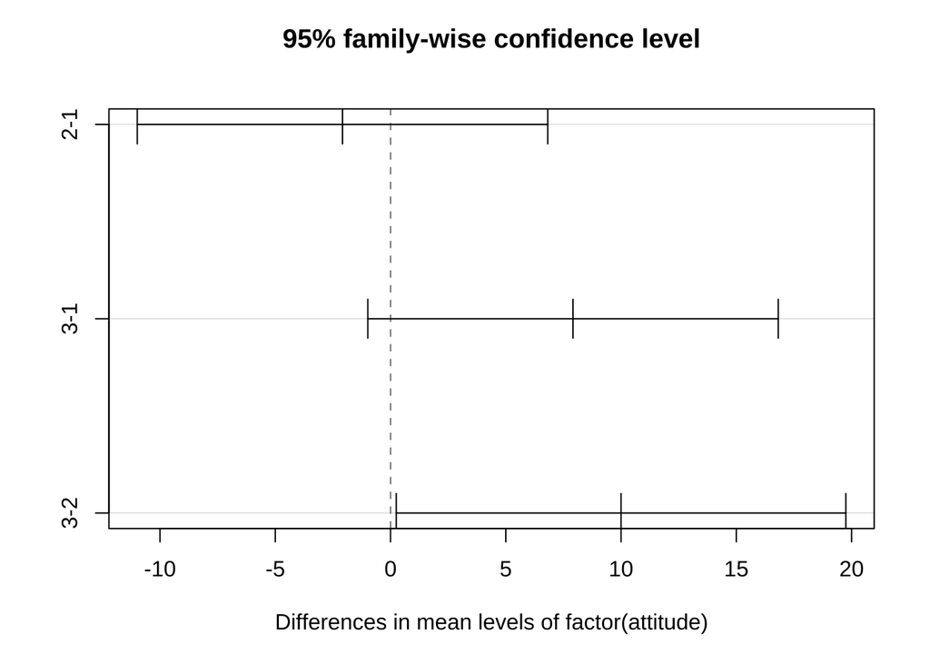

```r
# 可视化结果
plot(tukey.result)
```

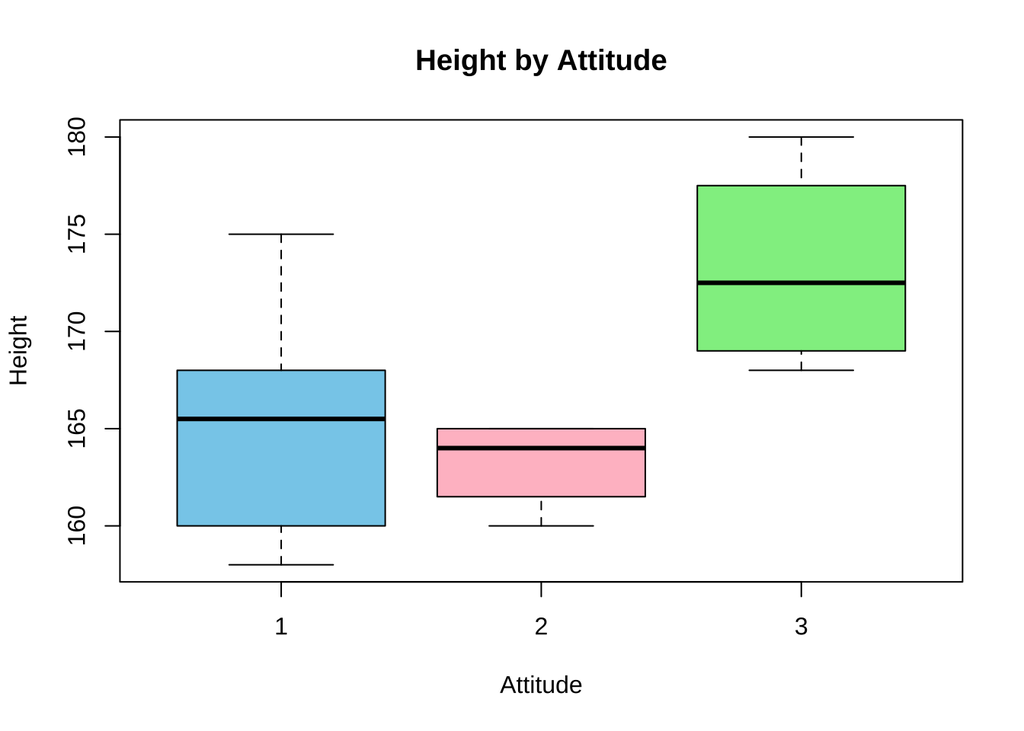

```r
boxplot(height ~ attitude, data = datafile,
        main = "Height by Attitude",
        xlab = "Attitude",
        ylab = "Height",
        col = c("skyblue", "pink", "lightgreen"))
```

# 回归分析

```r
datafile[1:5,] # 查看数据集的前5行
```

```
## # A tibble: 5 × 6
##      id gender height weight attitude   BMI
##   <dbl>  <dbl>  <dbl>  <dbl>    <dbl> <dbl>
## 1     1      1    180     85        3  26.2
## 2     2      0    165     62        2  22.8
## 3     3      0    168     65        1  23.0
## 4     4      1    175     65        1  21.2
## 5     5      1    165     63        1  23.1
```

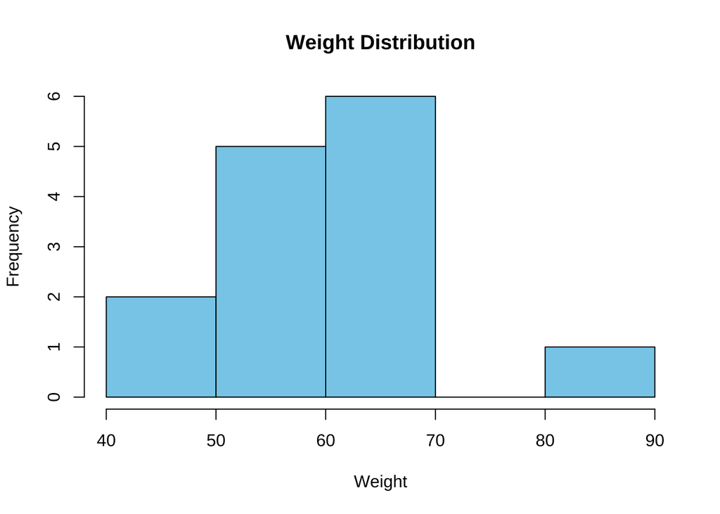

```r
#数据分布
hist(datafile$weight,
     main = "Weight Distribution",
     xlab = "Weight",
     ylab = "Frequency",
     col = "skyblue")
```

[figure not shown]

```r
hist(datafile$height,
     main = "Weight Distribution",
     xlab = "Weight",
     ylab = "Frequency",
     col = "skyblue")
```

```r
# 描述统计量
N  <-  sapply(datafile, length)
Mean  <-  sapply(datafile, mean)
SD  <-  sapply(datafile, sd)
Min <- sapply(datafile, min)
Med <- sapply(datafile, median)
Max <- sapply(datafile, max)
result <- cbind(N, Mean, SD, Min, Med, Max)
result
```

```
##           N       Mean         SD       Min       Med       Max
## id       14   7.500000  4.1833001   1.00000   7.50000  14.00000
## gender   14   0.500000  0.5188745   0.00000   0.50000   1.00000
## height   14 167.000000  6.3001831 158.00000 165.50000 180.00000
## weight   14  60.357143 10.0046692  45.00000  61.00000  85.00000
## attitude 14   1.857143  0.8644378   1.00000   2.00000   3.00000
## BMI      14  21.503286  2.1203676  18.02596  21.28123  26.23457
```

```r
# 箱式图
datafile$cat <- as.factor((datafile$weight > median(datafile$weight))*1)
head(datafile)
```

```
## # A tibble: 6 × 7
##      id gender height weight attitude   BMI cat
##   <dbl>  <dbl>  <dbl>  <dbl>    <dbl> <dbl> <fct>
## 1     1      1    180     85        3  26.2 1
## 2     2      0    165     62        2  22.8 1
## 3     3      0    168     65        1  23.0 1
## 4     4      1    175     65        1  21.2 1
## 5     5      1    165     63        1  23.1 1
## 6     6      1    168     60        3  21.3 0
```

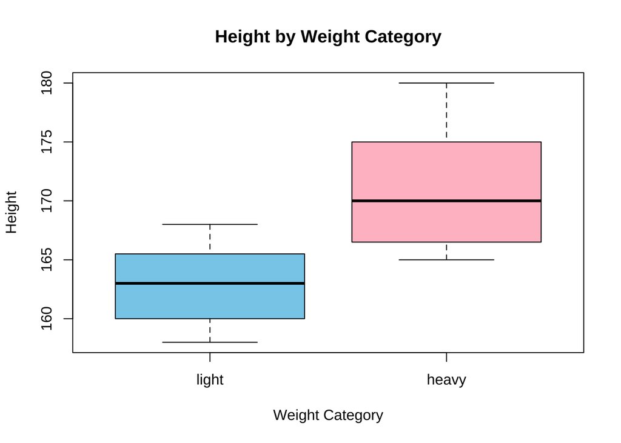

```r
levels(datafile$cat) <- c("light", "heavy")
boxplot(height ~ cat, data = datafile,
        main = "Height by Weight Category",
        xlab = "Weight Category",
        ylab = "Height",
        col = c("skyblue", "pink"))
```

```r
# 全模型
model <- lm(weight ~ height, data = datafile)
summary(model)
```

```
##
## Call:
## lm(formula = weight ~ height, data = datafile)
##
## Residuals:
##     Min      1Q  Median      3Q     Max
## -7.9114 -1.8930  0.0944  2.8386  5.8483
##
## Coefficients:
##              Estimate Std. Error t value Pr(>|t|)
## (Intercept) -181.0808    31.6915  -5.714 9.70e-05 ***
## height         1.4457     0.1896   7.623 6.14e-06 ***
## ---
## Signif. codes:  0 '***' 0.001 '**' 0.01 '*' 0.05 '.' 0.1 ' ' 1
##
## Residual standard error: 4.308 on 12 degrees of freedom
## Multiple R-squared:  0.8289, Adjusted R-squared:  0.8146
## F-statistic: 58.12 on 1 and 12 DF,  p-value: 6.138e-06
```

```r
# 模拟1000抽样80%的数据
nsimu <- 1000
ss <- nrow(datafile)
ss0 <- round(ss*0.8)
R2 <- rep(0,nsimu)

for (i in 1:nsimu) {
  index <- sample(1:ss, ss0)
  model <- lm(weight ~ height, data = datafile[index,])
  y.hat <- predict(model, datafile[-index,3])
  y.true <- datafile$weight[-index]
  R2[i] <- 1 - sum((y.true - y.hat)^2)/sum((y.true - mean(y.true))^2)
  R2[i] <- R2[i] * 100
}
head(R2)
```

```
## [1]  67.01724  77.41251  95.68766  58.71462  77.13235 -30.27099
```

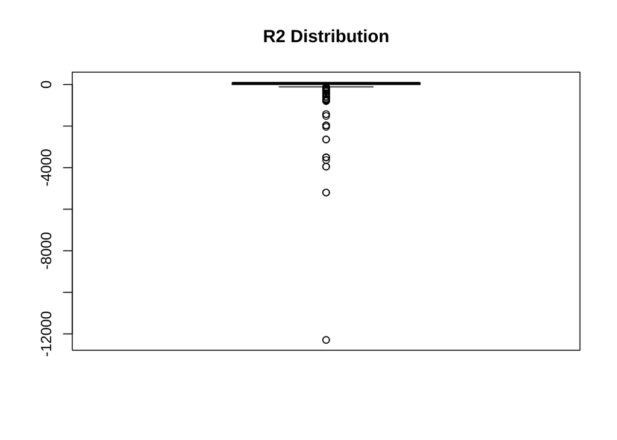

```r
boxplot(R2, main = "R2 Distribution", col = "skyblue")
```

```r
# 计算VIF
model <- lm(weight ~ height + gender, data = datafile)
vif(model)
```

```
##   height   gender
## 1.871503 1.871503
```

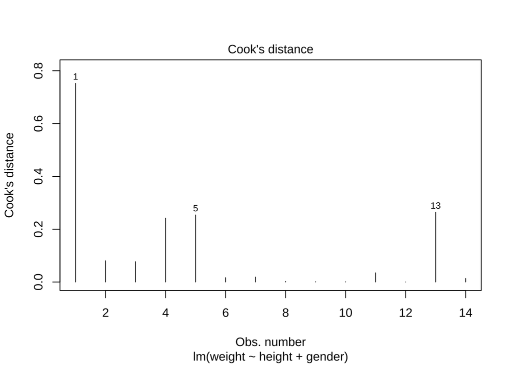

```r
# 计算Cook距离, 图示
plot(model, which = 4)
```

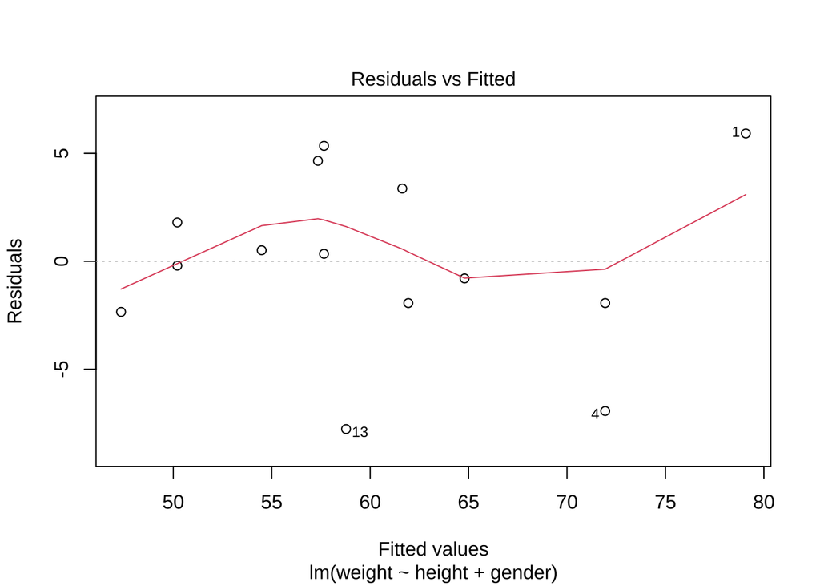

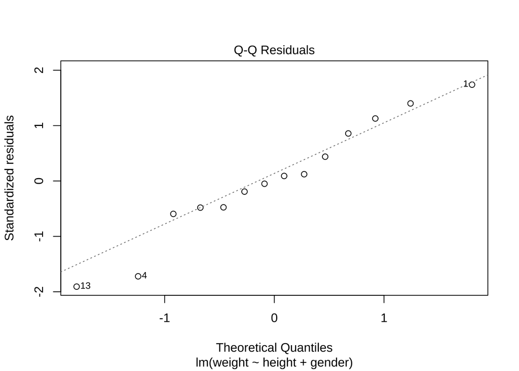

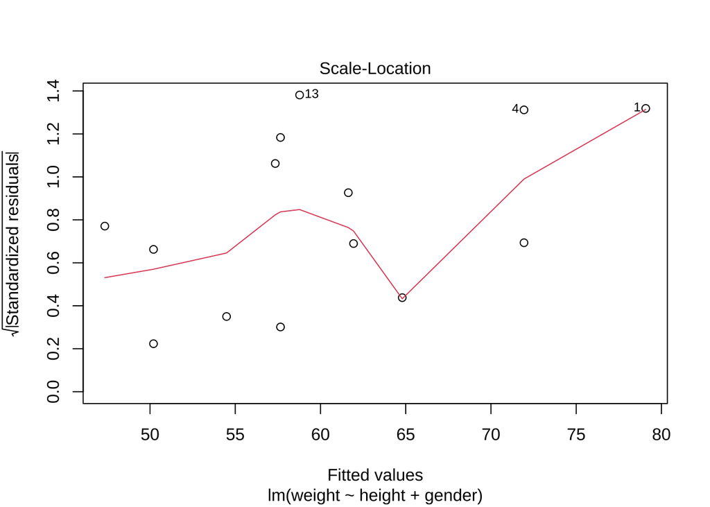

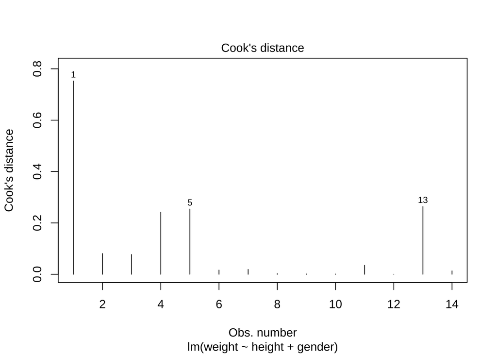

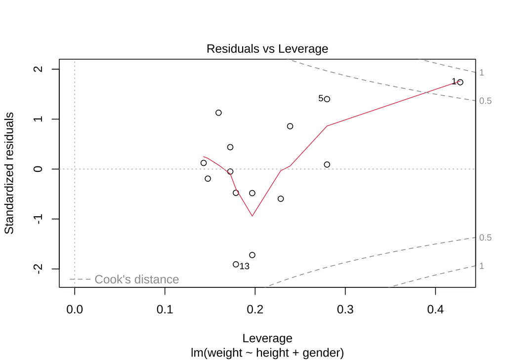

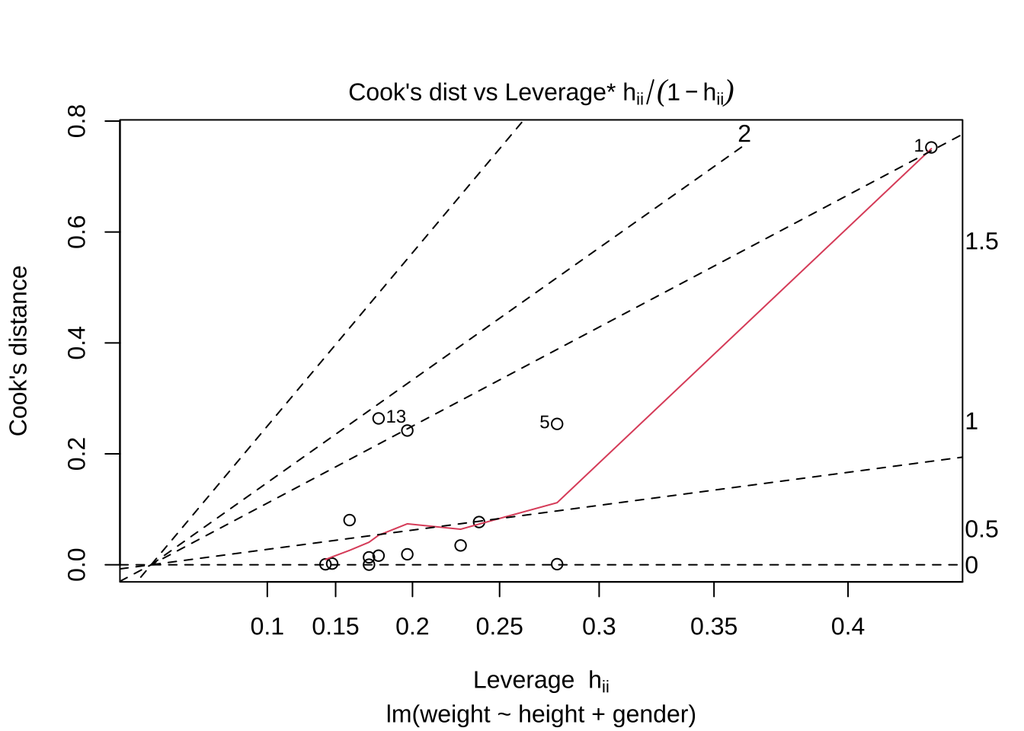

```r
# 残差分析，图示
plot(model, which = 1:6)
```

```r
# 模型的AIC，BIC
# 用于评估模型的优劣，特别是在平衡模型的拟合程度和复杂度时
# AIC()与step()中的AIC()结果不一样，相差一个常数nln(2pi)+n+2
model.aic <- step(model)
```

```
## Start:  AIC=44.72
## weight ~ height + gender
##
##          Df Sum of Sq    RSS    AIC
## - gender  1      0.18 222.69 42.734
## <none>                222.52 44.723
## - height  1    562.62 785.14 60.375
##
## Step:  AIC=42.73
## weight ~ height
##
##          Df Sum of Sq     RSS    AIC
## <none>                 222.69 42.734
## - height  1    1078.5 1301.21 65.448
```

```r
model.bic <- step(model, k = log(ss))
```

```
## Start:  AIC=46.64
## weight ~ height + gender
##
##          Df Sum of Sq    RSS    AIC
## - gender  1      0.18 222.69 44.013
## <none>                222.52 46.641
## - height  1    562.62 785.14 61.653
##
## Step:  AIC=44.01
## weight ~ height
##
##          Df Sum of Sq     RSS    AIC
## <none>                 222.69 44.013
## - height  1    1078.5 1301.21 66.087
```

```r
summary(model.aic)
```

```
##
## Call:
## lm(formula = weight ~ height, data = datafile)
##
## Residuals:
##     Min      1Q  Median      3Q     Max
## -7.9114 -1.8930  0.0944  2.8386  5.8483
##
## Coefficients:
##              Estimate Std. Error t value Pr(>|t|)
## (Intercept) -181.0808    31.6915  -5.714 9.70e-05 ***
## height         1.4457     0.1896   7.623 6.14e-06 ***
## ---
## Signif. codes:  0 '***' 0.001 '**' 0.01 '*' 0.05 '.' 0.1 ' ' 1
##
## Residual standard error: 4.308 on 12 degrees of freedom
## Multiple R-squared:  0.8289, Adjusted R-squared:  0.8146
## F-statistic: 58.12 on 1 and 12 DF,  p-value: 6.138e-06
```

```r
model.aic$anova[1,"AIC"]
```

```
## [1] 44.72337
```

```r
AIC(model)
```

```
## [1] 86.45365
```

```r
delta.aic <- AIC(model) - model.aic$anova[1,"AIC"]
delta.aic
```

```
## [1] 41.73028
```

```r
N[1]*log(2*pi) + N[1] + 2
```

```
##       id
## 41.73028
```

```r
# 人群细分
datafile$height_new <- as.factor((datafile$height > median(datafile$height))*1)
datafile$gender_new <- as.factor((datafile$gender > median(datafile$gender))*1)
table(datafile$height_new, datafile$gender_new)/nrow(datafile)
```

```
##
##             0         1
##   0 0.3571429 0.1428571
##   1 0.1428571 0.3571429
```

```r
table(datafile$gender_new)
```

```
##
## 0 1
## 7 7
```